# Em Busca do Sucesso: a trilha do caminho da fama

Flávia de Sousa Oliveira

27 de Março de 2021

[figure not shown]

## Introdução

Este relatório destina-se a todos que procuram alcançar o sucesso de crítica e de bilheteria para seus filmes sem o medo desse sonho acabar desembocando em sua falência pessoal e em seu nome estampado nas listas de negativados do Serasa. Se esse é seu caso, continue a leitura do relatório, pois nele vamos apresentar uma série de análises dos dados disponibilizados pela base de dados do IMDb para o perído dos últimos 16 anos.

De forma mais específica demonstraremos:

- Os 15 filmes com maiores lucros do período de 2000 até 2016;
- Os Diretores que podem levar seu filme a um sucesso de crítica e de bilheteria;
- As melhores composições técnicas para seu filme te levar ao caminho do sucesso(analisaremos dados sobre a cor, duração, gênero e classificação etária);
- Qual ator/atriz você deve contratar para ser a estrela principal de seu filme e te garantir corrida às bilheterias e aclamação da crítica.

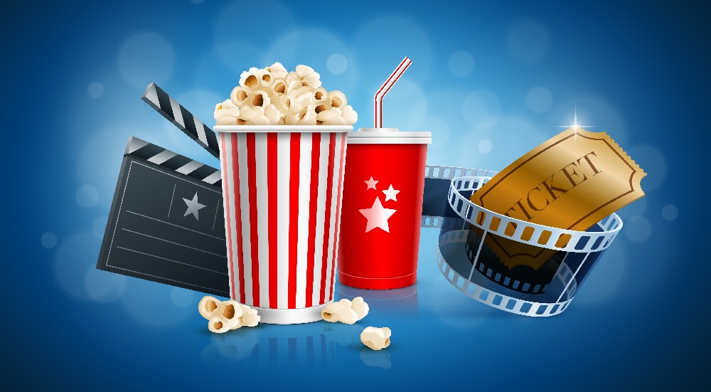

## A base IMDb

O IMDb é uma base de datos retirada do site do [IMDb](https://www.imdb.com/) - que é um site que funciona como um grande repositório de informações sobre filmes, cinema e música - e que contém informações de mais de três mil e setessentos filmes dos anos de 1916 até 2016. Sendo os filmes dos mais diversos diretores, de vários gêneros, duração e cor. Além disso, ela também informa sobre dados como orçamento, receita e a nota da crítica do IMDb para os filmes, bem como informa sobre atores e atrizes que compõem os filmes da base de dados.

## Por uma escolha segura: analisando os dados da base IMDb

Começamos nossa trilha ao caminho da fama observando quais foram os 15 filmes que tiveram os maiores lucros no período dos últimos 16 anos, ou seja, do período do ano 2000 até o ano de 2016.

| titulo | diretor | ano | cor | duracao | lucro |
| --- | --- | --- | --- | --- | --- |
| Avatar | James Cameron | 2009 | colorido | 178 | $523.505.847 |
| Jurassic World | Colin Trevorrow | 2015 | colorido | 124 | $502.177.271 |
| The Avengers | Joss Whedon | 2012 | colorido | 173 | $403.279.547 |
| The Dark Knight | Christopher Nolan | 2008 | colorido | 152 | $348.316.061 |
| The Hunger Games | Gary Ross | 2012 | colorido | 142 | $329.999.255 |
| Deadpool | Tim Miller | 2016 | colorido | 108 | $305.024.263 |
| The Hunger Games: Catching Fire | Francis Lawrence | 2013 | colorido | 146 | $294.645.577 |
| Despicable Me 2 | Pierre Coffin | 2013 | colorido | 98 | $292.049.635 |
| American Sniper | Clint Eastwood | 2014 | colorido | 133 | $291.323.553 |
| Finding Nemo | Andrew Stanton | 2003 | colorido | 100 | $286.838.870 |
| Shrek 2 | Andrew Adamson | 2004 | colorido | 93 | $286.471.036 |
| The Lord of the Rings: The Return of the King | Peter Jackson | 2003 | colorido | 192 | $283.019.252 |
| Star Wars: Episode III - Revenge of the Sith | George Lucas | 2005 | colorido | 140 | $267.262.555 |
| Spider-Man | Sam Raimi | 2002 | colorido | 121 | $264.706.375 |
| Minions | Kyle Balda | 2015 | colorido | 91 | $262.029.560 |

Calma! não tome decisões apressadas, vamos a analisar outros dados das variáveis da base IMDb para construirmos uma decisão mais apurada.

## Analizando os Diretores:

### Top 15 de Diretores, com mais de 3 filmes, que produziram mais filmes no período do últimos 16 anos

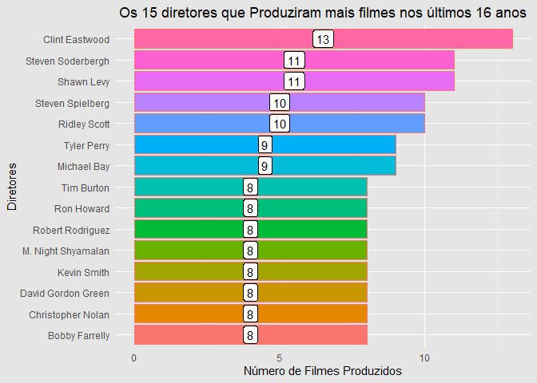

### Diretores, com mais de 3 filmes produzidos, que obtiveram melhores notas da crítica do IMDb no período dos últimos 16 por seus filmes

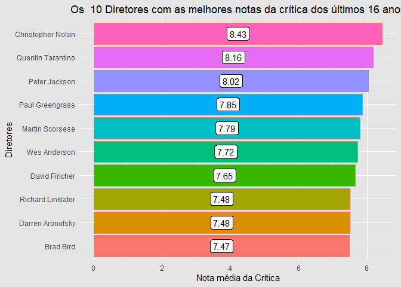

Como podemos observar, para um filme com sucesso de crítica do IMDb a boa aposta é chamar Christopher Nolan para a direção de seu filme. Todos os 8 filmes do diretor foram feitos no período dos últimos 16 anos. Sendo que sua menor nota da crítica foi 7.2 com o filme “Insomnia” e sua maior nota da crítica foi 9.0 com o filme “Batman:The Dark Knight”. Além disso, o diretor apresenta uma média de orçamento para seus filmes de $125.625.000 dollar.

Contudo Quentin Tarantino e Peter Jackson não ficam muito atrás e também podem ser boas escolhas. Eles apresentam uma média de orçamento para seus filmes de respectivamenta: $55.800.000 dollar e $131.600.000 dollar.

## Mas, Como fica os diretores com relação ao lucro?

Para melhorar nossa apuração de escolhas de diretor, apresenta-se a baixo uma relação do lucro em relação aos diretores mais bem avaliados pela crítica do IMDb

### Os Lucros dos diretores com maiores avaliações da crítica

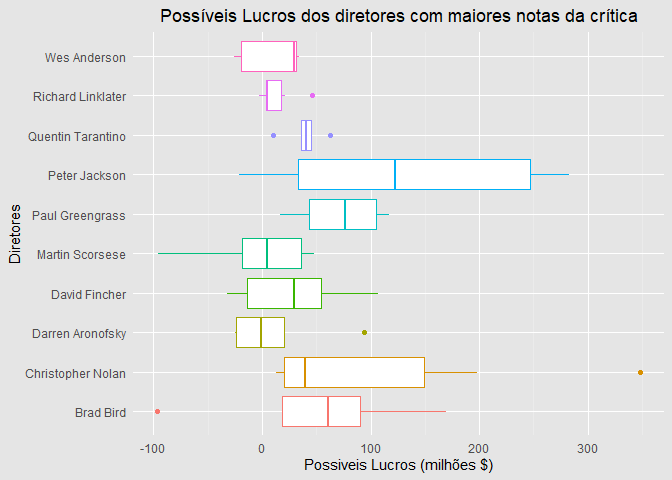

### Top 10 diretores com maiores lucros médios no período dos últimos 16 anos

| diretor | numero_filmes | lucro_medio |
| --- | --- | --- |
| Francis Lawrence | 5 | $151.100.394 |
| Peter Jackson | 5 | $132.967.515 |
| Andrew Adamson | 4 | $130.611.730 |
| Jay Roach | 4 | $113.092.240 |
| Sam Raimi | 5 | $109.714.997 |
| Christopher Nolan | 8 | $101.028.447 |
| Todd Phillips | 7 | $83.108.004 |
| Jon Favreau | 5 | $78.818.253 |
| Carlos Saldanha | 4 | $76.014.468 |
| James Wan | 7 | $73.468.029 |

### Top 10 diretores com piores lucros médios no período dos últimos 16 anos

| diretor | numero_filmes | lucro_medio |
| --- | --- | --- |
| McG | 6 | -$14.951.576 |
| Gary Fleder | 4 | -$15.378.659 |
| Rod Lurie | 4 | -$17.123.446 |
| Barry Levinson | 5 | -$17.337.724 |
| Guillermo del Toro | 4 | -$19.194.898 |
| Michael Mann | 4 | -$19.921.173 |
| Roland Emmerich | 6 | -$20.285.315 |
| Renny Harlin | 6 | -$21.290.952 |
| Rob Minkoff | 4 | -$33.224.989 |
| Martin Campbell | 4 | -$37.537.692 |

Como visto uma escolha entre Christopher Nolan e Peter Jackson para a direção de seu filme parece uma aposta mais acertada rumo a um filme de sucesso de crítica e de bilheteria. E, por outro lado, como podemos observar, é melhor fugir de Martin Campbell para direção de seu filme, pois com ele no comando o máximo que você vai conseguir é ver seu nome nos negativados do Serasa.

## Analisando os Aspectos Técnicos:

A seguir iremos analisar os dados referentes aos aspectos técnicos dos filmes, para garantir a escolha de uma composição do filme certeira, garantindo, assim, que ela tenha um lugar especial no coração do público e da crítica do IMDb.

## A Cor:

### Número de filmes coloridos e preto e branco nos últimos 16 anos

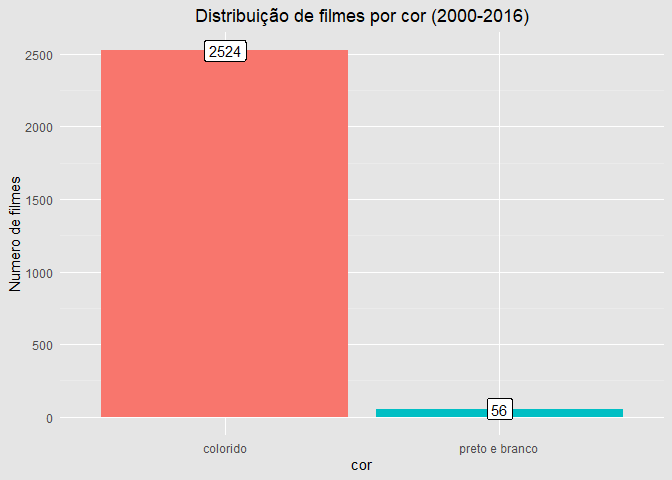

### Número de filmes coloridos e preto e branco por ano nos últimos 50 anos

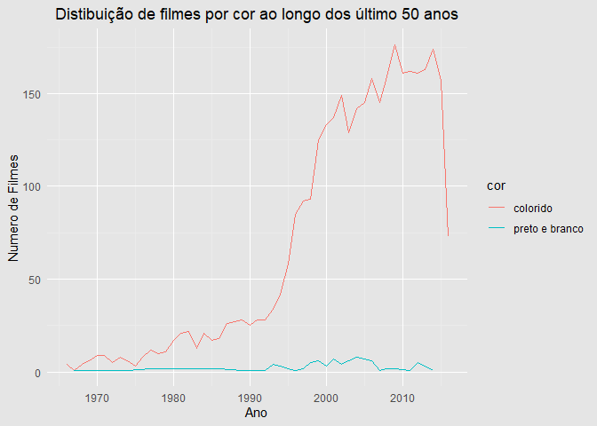

Como podemos observar, ao longo dos anos os filmes coloridos tornaram-se tendência para produções cinematográficas. Produzir um filme colorido, desse modo, é o mais indicado até para reduzir o risco de estranheza por parte do público em relação ao seu filme, o que pode afetar a receita. Contudo, caso se queira produzir um filme com uma cara mais vintage e menos comum é melhor optar pelo filme em preto em branco.

## Gênero:

### Distribuição do número de filme por gênero nos últimos 16 anos

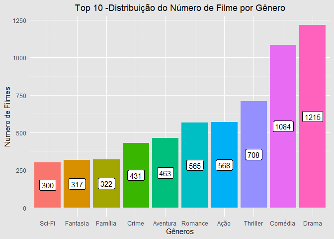

Como podemos observar, nos últimos 16 anos, os filmes mais produzidos - e avaliados pelo IMDb - foram dos gêneros de “Drama” e “Comédia”. O que indica uma preferência do público para o consumo desses dois gêneros de filme. Assim, um filme de drama ou de comédia pode te levar ao caminho do sucesso.

## A Duração:

### Relação entre duração e lucro para os filmes que lucraram nos último 16 anos

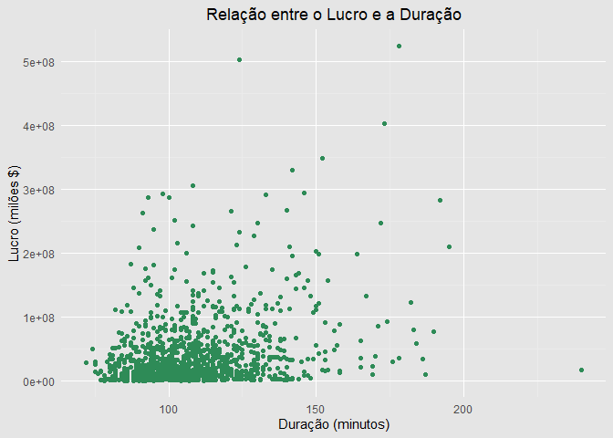

## Classificação Etária:

### Distribuição dos Filmes por Classificação Etária

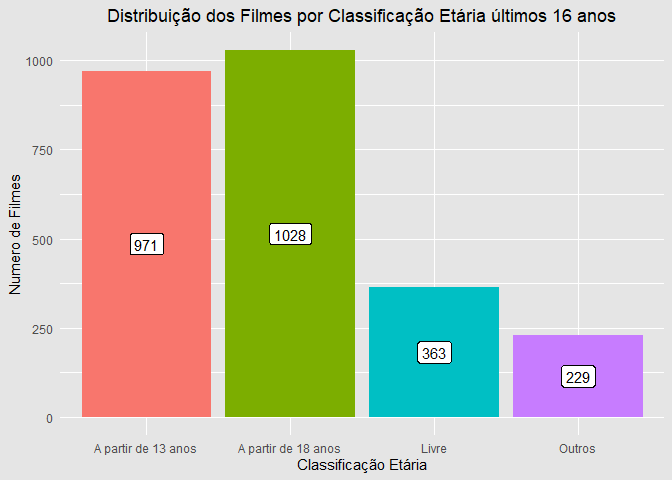

### Distribuição do Lucro por Classificação Etária para os ùltimos 16 anos

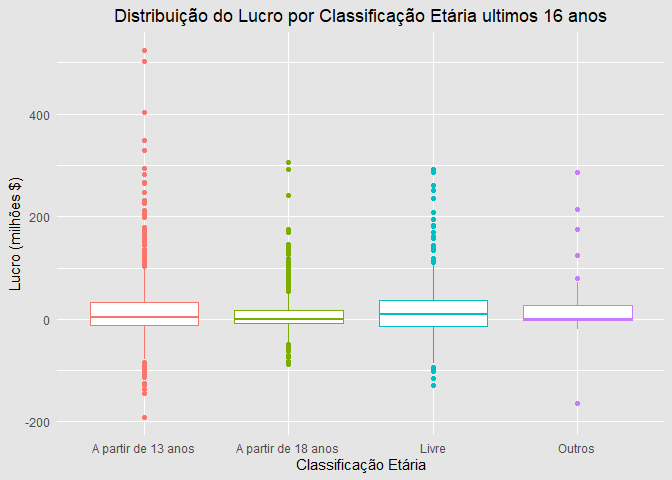

## Pensando o Elenco:

### Escolhento o Ator ou Atriz Principal:

Uma boa escolha da estrela principal que guiará seu filme é fundamental, pois ela pode garantir à sua produção uma corrida de público para as bilheterias e uma grande aclamação da crítica. Mas, essa escolha é muito complicada e demorada devido a diversidade de atores e atrizes.

Para te auxiliar nessa tarefa, nessa seção, foram selecionados os 15 atores principais - designados pela variável “ator_1” - que participaram de mais de três filmes do período de 2000 até 2016 e que partiparam de filmes que conseguiram boas avaliações da crítica, bem como de filmes muito lucrativos. Com esses dados em mãos, você consiguirá fazer uma boa escolha para a estrela de seu filme.

#### Os 15 Atores Principais com melhores notas média da crítica:

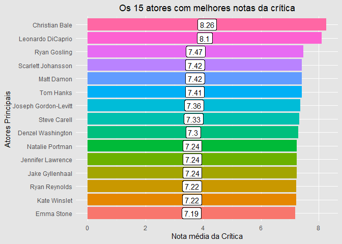

#### Como foi o Lucro Médio desses atores com melhores notas da crítica?

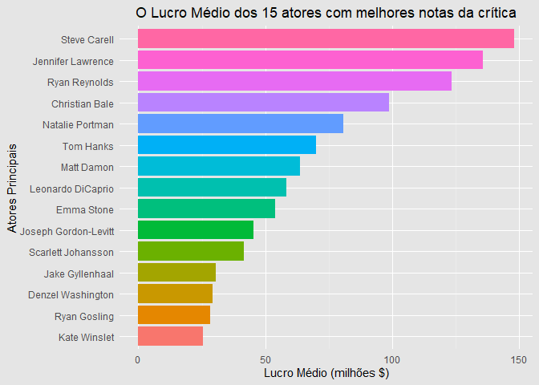

#### E se eu quiser uma estrela que garanta corrida para as bilheterias?

Nesse caso, apresentamos aqui os atores principais que estavam presentes em mais de três filmes dos últimos 16 anos e que obtiveram melhores lucros médios. Assim, o gráfico abaixo pode te auxiliar nessa tarefa

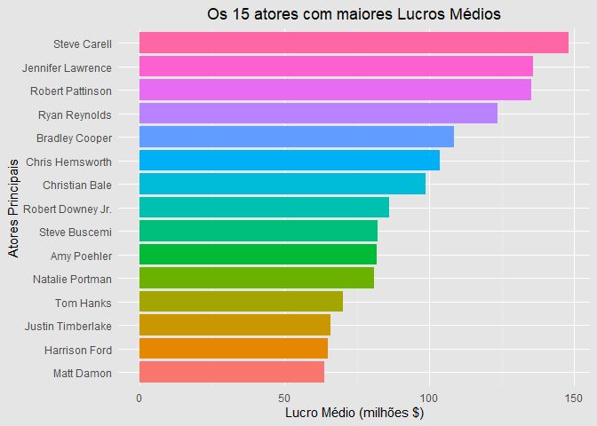

#### E a nota média da crítica desses atores com melhores lucros médios

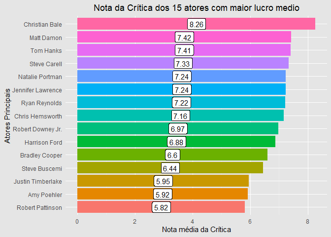

Com base no que foi apresentado, numa tentativa de conciliar um bom lucro e uma boa avaliação crítica vale apena chamar Christian Bale, Steve Carell, Natalie Portman, Jennifer Lawrence e Ryan Reynolds para serem sua estrele principal e acrescentarem brilho e dinheiro na sua produção cinematográfica.

Contudo, se você se preocupa apenas com o dinheiro no bolso, então apostar em Robert Pattinson e/ou Bradley Cooper também podem ser uma boa opção. Contudo, não espere grandes aclamações da crítica.

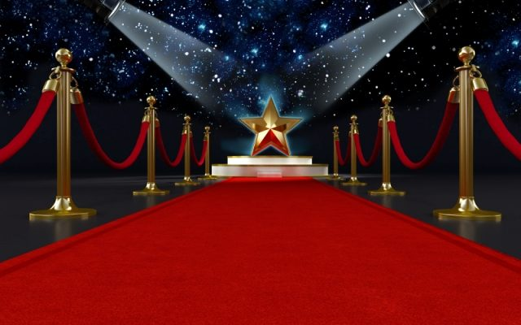

Agora, com essas informações em mãos, você pode caminhar tranquilamente rumo à fama e ao sucesso de bilheteria!